- ANOVA_design Function
- ANOVA_power Function
  - Two Group One-Way ANOVA
  - Three Between Subjects Conditions
  - Repeated Measures ANOVA
  - 2x2 ANOVA, Within-Between Design
  - Two-Way ANOVA, Between Participants Design
  - 2x2 ANOVA, Within Design

# An Introduction to ANOVApower

The goal of ANOVApower is to easily simulate ANOVA designs and calculate the observed power.

## Installation

You can install the released version of ANOVApower from [GitHub](https://github.com/Lakens/ANOVApower) with:

```r
devtools::install_github("Lakens/ANOVApower")
```

## ANOVA_design function

Currently the ANOVA_design function can create designs up three factors, for both within, between, and mixed designs. It requires the following input: string, n, mu, sd, r, and labelnames.

1. string: string that specifies the design (see below).
2. n: the sample size for each between subject condition.
3. mu: a vector with the means for each condition.
4. sd: the population standard deviation. Assumes homogeneity of variances (only one standard deviation can be provided).
5. r: the correlation for within designs (or 0 for between designs).
6. labelnames: This is an optonal vector of words that indicates factor names and level names (see below).
7. A final optional setting is to specify if you want to output a plot or not (plot = TRUE or FALSE)

### Specifying the design using ‘string’

‘string’ is used to specify the design. Every factor is specified with a number, indicating the numner of levels of the factor, and a letter, b or w, to indicate whether the factor is manipulated between or within participants. For example, a `2b` design has two between-participant groups. A `12w` design has one factor with 12 levels, all manipulated within-participants. A "2b*3w" is a design with two factors (a 2b factor and a 3w factor), the first of which has 2 between participant levels (2b), and the second of which has 3 within participants levels (3w). **If there are multiple factors (the functions take up to three different factors) seperate factors with a * (asterisk)**. An example of a `2b*3w` design is a group of people in one condition who get a drug, and a group of people in another condition who get a placebo, and we measure their health before they take the pill, one day after they take the pill, and a week after they take the pill.

### Specifying the means using ‘mu’

Note that for each cell in the design, a mean must be provided. Thus, for a "2b*3w" design, 6 means need to be entered.

Means need to be entered in the correct order. ANOVA_design outputs a plot so you can check if you entered all means as you intended. Always carefully check if the plot that is generated matches your expectations.

The general principle is that the code generates factors, indicated by the factor names you entered in the labelnames variable, (i.e., *condition* and *time*). Levels are indicated by factor names and levels (e.g., control_time1, control_time2, control_time3, etc).

If your design has just one factor, just enter the means in the same order as the labelnames (see below). For more factors, note the general pattern in the example below. Means are entered in the following order for a 3 factors design (each with 2 levels):

1. a1 b1 c1
2. a1 b1 c2
3. a1 b2 c1
4. a1 b2 c2
5. a2 b1 c1
6. a2 b1 c2
7. a2 b2 c1
8. a2 b2 c2

So if you enter the means 1, 2, 3, 4, 5, 6, 7, 8 the first 4 means correspond to level 1 of factor 1, the second 4 means correspond to level 2 of factor 1. Within the first 4 means, the first 2 correspond to level 1 of factor 2, and within those 2 means, the first corresponds to level 1 of factor 3.

The plot below visualizes means from 1 to 8 being entered in a vector: mu = c(1, 2, 3, 4, 5, 6, 7, 8) so you can see how the basic ordering works.

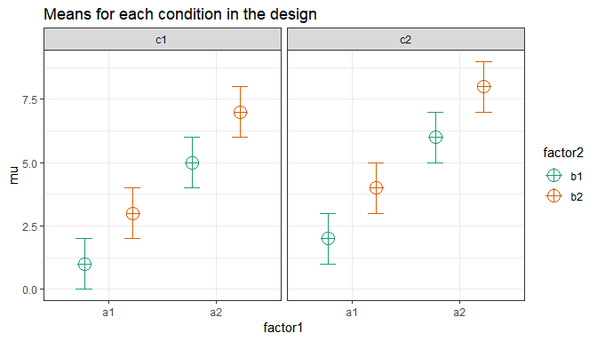

### Specifying label names

To make sure the plots and tables with simulation results are easy to interpret, it really helps to name all factors and levels. You can enter the labels in the ‘labelnames’ variable. You can also choose not to specify names. Then all factors are indicated by letters (a, b, c) and all levels by numbers (a1, a2, a3).

For the 2x3 design we have been using as an example, where there are 2 factors (condition and time of measurement), the first with 2 levels (placebo vs. medicine) and the second with three levels (time1, time2, and time3) we would enter the labels as follows:

c(“condition”, “placebo”, “medicine”, “time”, “time1”, “time2”, “time3”)

As you can see, you follow the order of the design (2b*3w), and first write the **FACTOR** label (condition) followed by the levels of that factor (placebo and medicine). Then you write the second factor name (time) followed by the three labels for each **LEVEL** (time1, time2, time3). **Do not use spaces in the names (so not “time 1” but “time1” or “time_1”).**

### Specifying the correlation

Depending on whether factors are manipulated within or between, variables are correlated, or not. You can set the correlation for within-participant factors. You can either assume all factors have the same correlation (e.g., r = 0.7), or enter the correlations for each pair of observations seperately by specifying a correlation matrix.

#### Specifying the correlation matrix.

In a 2x2 within-participant design, with factors A and B, each with 2 levels, there are 6 possible comparisons that can be made.

1. A1 vs. A2
2. A1 vs. B1
3. A1 vs. B2
4. A2 vs. B1
5. A2 vs. B2
6. B1 vs. B2

The number of possible comparisons is the product of the levels of all factors squared minus the product of all factors, divided by two. For a 2x2 design where each factor has two levels, this is:

```r
(((2*2)^2)-(2*2))/2
```

```
## [1] 6
```

The number of possible comparisons increases rapidly when adding factors and levels for each factor. For example, for a 2x2x4 design it is:

```r
(((2*2*4)^2)-(2*2*4))/2
```

```
## [1] 120
```

Each of these comparisons can have their own correlation if the factor is manipulated within subjects (if the factor is manipulated between subjects the correlation is 0). These correlations determine the covariance matrix. Potvin and Schutz (2000) surveyed statistical tools for power analysis and conclude that most software packages are limited to one factor repeated measure designs and do not provide power calculations for within designs with multiple factor (which is still true for software such as G*Power). Furthermore, software solutions which were available at the time (DATASIM by Bradley, Russel, & Reeve, 1996) required researchers to assume correlations were of the same magnitude for all within factors, which is not always realistic. If you do not want to assume equal correlations for all paired comparisons, you can specify the correlation for each possible comparison.

The order in which the correlations are entered in the vector should match the covariance matrix. The order for a 2x2 design is given in the 6 item list above. The general pattern is that the matrix is filled from top to bottom, and left to right, illustrated by the increasing correlations in the table below.

| Factor | a1_b1 | a1_b2 | a2_b1 | a2_b2 |
| --- | --- | --- | --- | --- |
| a1_b1 | 1.00 | 0.91 | 0.92 | 0.93 |
| a1_b2 | 0.91 | 1.00 | 0.94 | 0.95 |
| a2_b1 | 0.92 | 0.94 | 1.00 | 0.96 |
| a2_b2 | 0.93 | 0.95 | 0.96 | 1.00 |

The diagonal is generated dynamically (and all conditions are perfectly correlated with themselves).

We would enter this correlation matrix as:

```r
design_result <- ANOVA_design(string = "2w*2w",
                              n = 80,
                              mu = c(1.1, 1.2, 1.3, 1.4),
                              sd = 2,
                              r <- c(0.91, 0.92, 0.93, 0.94, 0.95, 0.96))
```

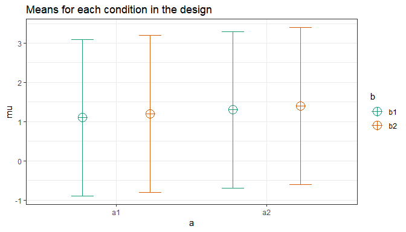

We can check the correlation matrix by asking for it from the design_result object to check if it was entered the way we wanted:

```r
design_result$cor_mat
```

```
##       a1_b1 a2_b1 a1_b2 a2_b2
## a1_b1     1     0     0     0
## a2_b1     0     1     0     0
## a1_b2     0     0     1     0
## a2_b2     0     0     0     1
```

Note that we did not specify the labelnames, and thus they are automatically created.

### Specifying the sample size

You can set the sample size **per condition** by setting a value for n. The assumption is that you will collect equal sample sizes in all conditions.

### Specifying the standard deviation

You can set the standard deviation by setting a value of sd. Note that there is always some uncertainty in which values you can expect in the study you are planning. It is therefore useful to perform sensitivity analyses (e.g., running the simulation with the expected standard deviation, but also with more conservative or even worst-case-scenario values).

## The ANOVA_power function

The ANOVA_power function takes the result from the ANOVA_design function, and simulates data nsims times using a specified alpha level. As output, it provides a table for the ANOVA results, and the results for all independent comparisons.

It requires the following input: ANOVA_design, alpha_level, p_adjust, nsims, seed, and verbose.

1. design_result: Output from the ANOVA_design function saved as an object
2. alpha_level: Alpha level used to determine statistical significance
3. p_adjust: Correction for multiple comparisons using the p.adjust function
4. nsims: number of simulations to perform
5. seed: Set seed for reproducible results
6. verbose: Set to FALSE to not print results (default = TRUE)

Simulations typically take some time. Larger numbers of simulations yield more accurate results, but also take a long time. I recommend testing the set up with 10 simulations, and run 1000 if the set-up is correct (or 10000 if you are getting a coffee, or 100.000 if you are about accuracy to digits behind the decimal).

## An Example

```r
design_result <- ANOVA_design(string = "2b*2w",
                   n = 40,
                   mu = c(1.03, 1.41, 0.98, 1.01),
                   sd = 1.03,
                   r=0.8,
                   labelnames = c("voice", "human", "robot", "emotion", "cheerful", "sad"))
```

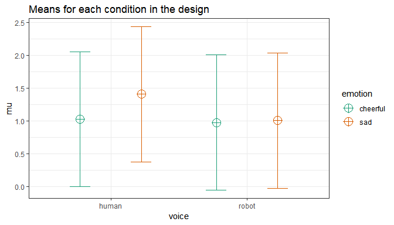

```r
power_result <- ANOVA_power(design_result,
                                 alpha = 0.05,
                                 nsims = nsims,
                                 seed = 1234)
```

```
## Power and Effect sizes for ANOVA tests
##                     power effect_size
## anova_voice         18.04      0.0148
## anova_emotion       79.89      0.0929
## anova_voice:emotion 66.51      0.0694
##
## Power and Effect sizes for contrasts
##                                                             power
## p_voice_human_emotion_cheerful_voice_human_emotion_sad      95.06
## p_voice_human_emotion_cheerful_voice_robot_emotion_cheerful  5.35
## p_voice_human_emotion_cheerful_voice_robot_emotion_sad       5.13
## p_voice_human_emotion_sad_voice_robot_emotion_cheerful      45.74
## p_voice_human_emotion_sad_voice_robot_emotion_sad           40.73
## p_voice_robot_emotion_cheerful_voice_robot_emotion_sad       6.16
##                                                             effect_size
## p_voice_human_emotion_cheerful_voice_human_emotion_sad           0.5949
## p_voice_human_emotion_cheerful_voice_robot_emotion_cheerful     -0.0489
## p_voice_human_emotion_cheerful_voice_robot_emotion_sad          -0.0198
## p_voice_human_emotion_sad_voice_robot_emotion_cheerful          -0.4217
## p_voice_human_emotion_sad_voice_robot_emotion_sad               -0.3928
## p_voice_robot_emotion_cheerful_voice_robot_emotion_sad           0.0464
```

The result for the power simulation has two sections (which can be surpressed by setting verbose = FALSE). The first table provides power (from 0 to 100%) and effect sizes (partial eta-squared) for the ANOVA result. We see the results for the main effects of factor voice, emotion, and the voice*emotion interaction.

The result for the power simulation reveal power is highest for the main effect of emotion. Remember that this is the within-subjects factor, and the means are highly correlated (0.8) - so we have high power for within comparisons. Power is lower for the interaction, and very low for the main effect of voice.

An ANOVA is typically followed up with contrasts. A statistical hypothesis often predicts not just an interaction, but also the shape of an interaction. For example, when looking at the plot of our design above, we might be specifically interested in comparing the independent effect for the cheerful vs sad human voice assistant, and the difference for sad voice when they are robotic or human. The second table provides the power for *t*-tests for all comparisons, and the effect sizes (Cohen’s d for between-subject contrasts, and Cohen’s (d_z) for within-subject contrasts, see [Lakens, 2013](https://www.frontiersin.org/articles/10.3389/fpsyg.2013.00863/full)).

Power is relatively high for the differences between within-participant conditions, and power is very low for the minor differences among the three similar means (1.03, 0.98, 1.01). In addition to the two tables, the ANOVA_power function returns the raw simulation data (all p-values and effect sizes for each simulation, use simulation_result$sim_data) and a plot showing the *p*-value distributions for all tests in the ANOVA.

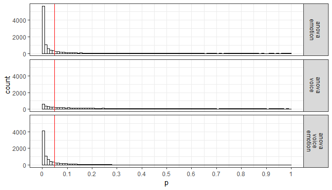

```r
power_result$plot1
```

## Power in a Two Group One-Way ANOVA

Imagine we aim to design a study to test the hypothesis that giving people a pet to take care of will increase their life satisfaction. We have a control condition, and a condition where people get a pet, and randomly assign participants to either condition. We can simulate a One-Way ANOVA with a specified alpha, sample size, and effect size, on see which statistical power we would have for the ANOVA. We expect pets to increase life-satisfaction compared to the control condition. Based on work by Pavot and Diener (1993) we believe that we can expect responses on the life-satifaction scale to have a mean of approximately 24 in our population, with a standard deviation of 6.4. We expect having a pet increases life satisfaction with approximately 2.2 scale points for participants who get a pet. We plan to collect data from 200 participants in total, with 100 participants in each condition. We examine the statistical power our design would have to detect the differences we predict.

```r
string <- "2b"
n <- 100
mu <- c(24, 26.2)
sd <- 6.4
labelnames <- c("condition", "control", "pet") #

design_result <- ANOVA_design(string = string,
                              n = n,
                              mu = mu,
                              sd = sd,
                              labelnames = labelnames)
```

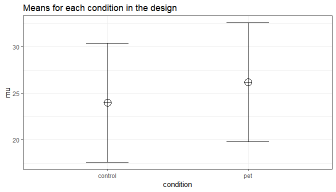

```r
ANOVA_power(design_result, nsims = nsims)
```

```
## Power and Effect sizes for ANOVA tests
##                 power effect_size
## anova_condition 67.73      0.0288
##
## Power and Effect sizes for contrasts
##                                   power effect_size
## p_condition_control_condition_pet 67.73       0.344
```

```r
#Note we do not specify any correlation in the ANOVA_design function (default r = 0), nor do we specify an alpha in the ANOVA_power function (default is 0.05)
```

The result shows that we have exactly the same power for the ANOVA, as we have for the *t*-test. This is because when there are only two groups, these tests are mathematically identical. In a study with 100 participants per condition, we would have quite low power (around 67.7%). An ANOVA with 2 groups is identical to a *t*-test. For our example, Cohen’s d (the standardized mean difference) is 2.2/6.4, or d = 0.34375 for the difference between the control condition and having pets, which we can use to easily compute the expected power for these simple comparisons using the pwr package.

```r
library(pwr)
pwr.t.test(d = 2.2/6.4,
           n = 100,
           sig.level = 0.05,
           type="two.sample",
           alternative="two.sided")$power
```

```
## [1] 0.6768572
```

We can also directly compute Cohen’s f from Cohen’s d for two groups, as Cohen (1988) describes, because f = (\frac{1}{2}d). So f = 0.5*0.34375 = 0.171875. And indeed, power analysis using the pwr package yields the same result using the pwr.anova.test as the power.t.test.

```r
pwr.anova.test(n = 100,
               k = 2,
               f = 0.171875,
               sig.level = 0.05)$power
```

```
## [1] 0.6768572
```

This analysis tells us that running the study with 100 participants in each condition is too likely to *not* yield a significant test result, even if our expected pattern of differences is true. This is not optimal.

How many participants do we need for sufficient power? Given the expected difference and standard deviation, d = 0.34375, and f = 0.171875, we can increase the number of participants and run the simulation until we are content. We need 179 participants in each group, or 358 in total, to have 90% power.

```r
string <- "2b"
n <- 179
mu <- c(24, 26.2)
sd <- 6.4
labelnames <- c("condition", "control", "pet") #
design_result <- ANOVA_design(string = string,
                   n = n,
                   mu = mu,
                   sd = sd,
                   labelnames = labelnames)
```

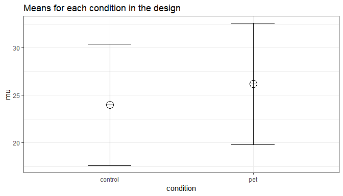

```r
power_result <- ANOVA_power(design_result, nsims = nsims)
```

```
## Power and Effect sizes for ANOVA tests
##                 power effect_size
## anova_condition    90      0.0287
##
## Power and Effect sizes for contrasts
##                                   power effect_size
## p_condition_control_condition_pet    90      0.3434
```

## Three between subject conditions

Imagine we aim to design a study to test the hypothesis that giving people a pet to take care of will increase their life satisfaction. We have a control condition, a ‘cat’ pet condition, and a ‘dog’ pet condition. We can simulate a One-Way ANOVA with a specified alpha, sample size, and effect size, on see the statistical power we would have for the ANOVA and the follow-up comparisons. We expect all pets to increase life-satisfaction compared to the control condition. Obviously, we also expect the people who are in the ‘dog’ pet condition to have even greater life-satisfaction than people in the ‘cat’ pet condition. Based on work by Pavot and Diener (1993) we believe that we can expect responses on the life-satisfaction scale to have a mean of approximately 24 in our population, with a standard deviation of 6.4. We expect having a pet increases life satisfaction with approximately 2.2 scale points for participants who get a cat, and 2.6 scale points for participants who get a dog. We initially consider collecting data from 150 participants in total, with 50 participants in each condition. But before we proceed with the data collection, we examine the statistical power our design would have to detect the differences we predict.

```r
string <- "3b"
n <- 50
mu <- c(24, 26.2, 26.6)
sd <- 6.4
labelnames <- c("condition", "control", "cat", "dog") #

design_result <- ANOVA_design(string = string,
                   n = n,
                   mu = mu,
                   sd = sd,
                   labelnames = labelnames)
```

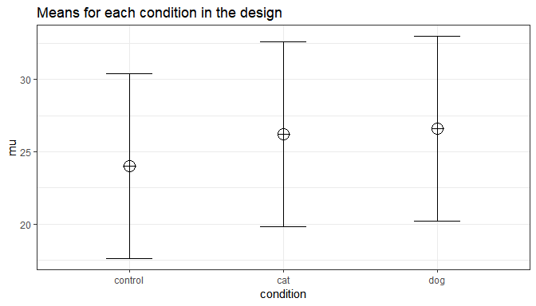

```r
ANOVA_power(design_result, nsims = nsims)
```

```
## Power and Effect sizes for ANOVA tests
##                 power effect_size
## anova_condition 48.14      0.0384
##
## Power and Effect sizes for contrasts
##                                   power effect_size
## p_condition_control_condition_cat 39.45      0.3453
## p_condition_control_condition_dog 52.54      0.4095
## p_condition_cat_condition_dog      6.00      0.0642
```

The result shows that you would have quite low power with 50 participants, both for the overall ANOVA (just around 50% power), as for the follow up comparisons (approximately 40% power for the control vs cat condition, around 50% for the control vs dogs condition, and a really low power (around 6%, just above the Type 1 error rate of 5%) for the expected difference between cats and dogs. We can easily confirm the expected power for these simple comparisons using the pwr package. For our example, Cohen’s d (the standardized mean difference) is 2.2/6.4, or d = 0.34375 for the difference between the control condition and cats, 2.6/6.4 of d = 0.40625 for the difference between the control condition and dogs, and 0.4/6.4 or d = 0.0625 for the difference between cats and dogs as pets.

```r
pwr.t.test(d = 2.2/6.4,
           n = 50,
           sig.level = 0.05,
           type="two.sample",
           alternative="two.sided")$power
```

```
## [1] 0.3983064
```

```r
pwr.t.test(d = 2.6/6.4,
           n = 50,
           sig.level = 0.05,
           type="two.sample",
           alternative="two.sided")$power
```

```
## [1] 0.5205162
```

```r
pwr.t.test(d = 0.4/6.4,
           n = 50,
           sig.level = 0.05,
           type="two.sample",
           alternative="two.sided")$power
```

```
## [1] 0.06104044
```

## Power in Repeated Measures ANOVA

In a repeated measures design multiple observations are collected from the same participants. In the simplest case, where there are two repeated observations, a repeated measures ANOVA equals a dependent or paired *t*-test. Let’s explore the impact of this correlation on the power of a repeated measures ANOVA.

### Two within conditions

To illustrate the effect of correlated observations, we start by simulating data for a medium effect size for a dependent (or paired, or within-subject) *t*-test. Let’s first look at G*power. If we want to perform an a-priori power analysis, we are asked to fill in the effect size (d_z). As Cohen (1988) writes, “The Z subscript is used to emphasize the fact that our raw score unit is no longer X or Y, but Z”, where Z are the difference scores of X-Y.

[figure not shown]

Within designs can have greater power to detect differences than between designs because the values are correlated, and a within design requires less participants because each participant provides multiple observations. One difference between an independent *t*-test and a dependent *t*-test is that an independent *t*-test has 2(n-1) degrees of freedom, while a dependent *t*-test has (n-1) degrees of freedom. The sample size needed in a two-group within-design (NW) relative to the sample needed in two-group between-designs (NB), assuming normal distributions, and ignoring the difference in degrees of freedom between the two types of tests, is (from Maxwell & Delaney, 2004, p. 561, formula 45):

(N_{W}=\frac{N_{B}(1-\rho)}{2})

The division by 2 in the equation is due to the fact that in a two-condition within design every participant provides two data-points. The extent to which this reduces the sample size compared to a between-subject design depends on the correlation (*r*) between the two dependent variables, as indicated by the 1-r part of the equation. If the correlation is 0, a within-subject design needs half as many participants as a between-subject design (e.g., 64 instead 128 participants), simply because every participants provides 2 datapoints. The higher the correlation, the larger the relative benefit of within designs, and whenever the correlation is negative (up to -1) the relative benefit disappears.

Whereas in an independent *t*-test the two observations are uncorrelated, in a within design the observations are correlated. This has an effect on the standard deviation of the difference scores. In turn, because the standardized effect size is the mean difference divided by the standard deviation of the difference scores, the correlation has an effect on the standardized mean difference in a within design, Cohen’s (d_z). The relation, as Cohen (1988, formula 2.3.7) explains, is:

(\sigma_{z}=\sigma\sqrt{2(1-\rho)})

Therefore, the relation between dz and d is (\sqrt{2(1-\rho)}). As Cohen (1988) writes: "In other words, a given difference between population means for matched (dependent) samples is standardized by a value which is (\sqrt{2(1-\rho)}) as large as would be the case were they independent. If we enter a correlation of 0.5 in the formula, we get (\sqrt{2(0.5)}=1). When the correlation is 0.5, d = (d_z). When there is a strong correlation between dependent variables, for example r = 0.9, we get (d=d_{z}\sqrt{2(1-0.9)}), and a (d_z) of 1 would be a d = 0.45. Reversely, (d_{z}=\frac{d}{\sqrt{2(1-r)}}), so with a r = 0.9, a d of 1 would be a (d_z) = 2.24. Some consider this increase in (d_z) compared to d when observations are strongly correlated an ‘inflation’ when estimating effect sizes, but since the reduction in the standard deviation of the difference scores due to the correlation makes it easier to distinguish signal from noise in a hypothesis test, it leads to a clear power benefit.

There is no equivalent (f_z) for Cohen’s f for a within subject ANOVA. For two groups, we can directly compute Cohen’s f from Cohen’s d, as Cohen (1988) describes, because f = (\frac{1}{2}d). For a d = 0.5, f = 0.25. In G*power we can run a 2 group within-subject power analysis for ANOVA. We plan for 80% power, and reproduce the anaysis above for the dependent *t*-test. This works because the correlation is set to 0.5, when d = (d_z), and thus the transformation of f=(\frac{1}{2}d) works.

[figure not shown]

If we change the correlation to 0.7 and keep all other settings the same, the repeated measure a-priori power analysis yields a sample of 21. The correlation increases the power for the test.

[figure not shown]

To reproduce this analysis in G*power with a dependent *t*-test we need to change (d_z) following the formula above, (d_{z}=\frac{0.5}{\sqrt{2(1-0.7)}}), which yields (d_z) = 0.6454972. If we enter this value in G*power for an a-priori power analysis, we get the exact same results (as we should, since an repeated measures ANOVA with 2 groups equals a dependent *t*-test). This example illustrates that the correlation between dependent variables always factors into a power analysis, both for a dependent *t*-test, and for a repeated measures ANOVA. Because a dependent *t*-test uses (d_z) the correlation might be less visible, but given the relation between d and (d_z), the correlation is always taken into account and can greatly improve power for within designs compared to between designs.

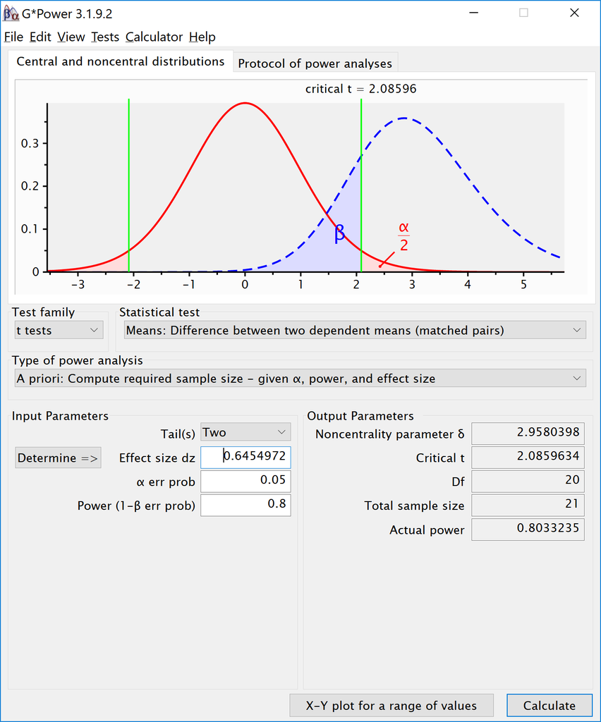

```r
K <- 2
n <- 34
sd <- 1
r <- 0.5
alpha = 0.05
f <- 0.25
f2 <- f^2
ES <- f2/(f2+1)
ES
```

```
## [1] 0.05882353
```

```r
mu <- mu_from_ES(K = K, ES = ES)
string = paste(K,"w",sep="")
labelnames <- c("speed", "fast", "slow")

design_result <- ANOVA_design(string = string,
                              n = n,
                              mu = mu,
                              sd = sd,
                              r = r,
                              labelnames = labelnames)
```

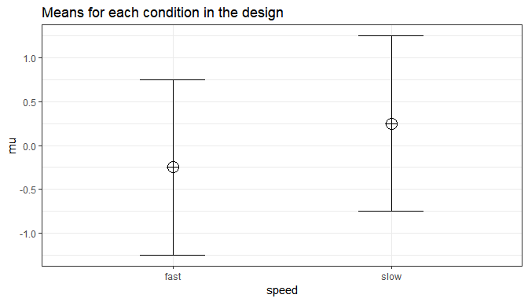

```r
ANOVA_power(design_result, nsims = nsims)
```

```
## Power and Effect sizes for ANOVA tests
##             power effect_size
## anova_speed 51.91      0.1165
##
## Power and Effect sizes for contrasts
##                         power effect_size
## p_speed_fast_speed_slow 53.08      0.5057
```

```r
K <- 2
n <- 21
sd <- 1
r <- 0.7
alpha = 0.05
f <- 0.25
f2 <- f^2
ES <- f2/(f2+1)
ES
```

```
## [1] 0.05882353
```

```r
mu <- mu_from_ES(K = K, ES = ES)
string = paste(K,"w",sep="")
labelnames <- c("speed", "fast", "slow")

design_result <- ANOVA_design(string = string,
                              n = n,
                              mu = mu,
                              sd = sd,
                              r = r,
                              labelnames = labelnames)
```

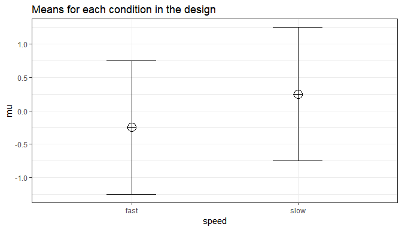

```r
ANOVA_power(design_result, nsims = nsims)
```

```
## Power and Effect sizes for ANOVA tests
##             power effect_size
## anova_speed 33.98      0.1197
##
## Power and Effect sizes for contrasts
##                         power effect_size
## p_speed_fast_speed_slow 35.36      0.5131
```

### Power in Repeated Measures ANOVA with More than 2 Groups

We will examine a repeated measures experiment with 3 within-participant conditions, to illustrate how a repeated measures ANOVA extends a dependent *t*-test. In the example for a two-group within design we provided a specific formula for the sample size benefit for two groups. The sample size needed in within-designs (NW) with more than 2 conditions, relative to the sample needed in between-designs (NB), assuming normal distributions and compound symmetry, and ignoring the difference in degrees of freedom between the two types of tests, is (from Maxwell & Delaney, 2004, p. 562, formula 47):

(N_{W}=\frac{N_{B}(1-\rho)}{a})

Where a is the number of within-subject levels.

### The relation between Cohen’s f and Cohen’s d

Whereas in the case of a repeated measures ANOVA with 2 groups we could explain the principles of a power analysis by comparing our test against a *t*-test and Cohen’s d, this becomes more difficult when we have more than 2 groups. It is more useful to explain how to directly calculate Cohen’s f, the effect size used in power analyses for ANOVA. Cohen’s f is calculated following Cohen, 1988, formula 8.2.1 and 8.2.2:

(f = \sqrt{\frac{\frac{\sum(\mu-\overline{\mu})^2)}N}\sigma})

Imagine we have a within-subject experiment with 3 conditions. We ask people what they mood is when their alarm clock wakes them up, when they wake up naturally on a week day, and when they wake up naturally on a weekend day. Based on pilot data, we expect the means (on a 7 point validated mood scale) are 3.8, 4.2, and 4.3. The standard deviation is 0.9, and the correlation between the dependent measurements is 0.7. We can calculate Cohen’s f for the ANOVA, and Cohen’s dz for the contrasts:

```r
mu <- c(3.8, 4.2, 4.3)
sd <- 0.9
f <- sqrt(sum((mu-mean(mu))^2)/length(mu))/sd #Cohen, 1988, formula 8.2.1 and 8.2.2
f
```

```
## [1] 0.2400274
```

```r
r <- 0.7
(4.2-3.8)/0.9/sqrt(2*(1-r))
```

```
## [1] 0.5737753
```

```r
(4.3-3.8)/0.9/sqrt(2*(1-r))
```

```
## [1] 0.7172191
```

```r
(4.3-4.2)/0.9/sqrt(2*(1-r))
```

```
## [1] 0.1434438
```

The relation between Cohen’s d or dz and Cohen’s f becomes more difficult when there are multiple groups, because the relationship depends on the pattern of the means. Cohen (1988) presents calculations for three patterns, minimal variability (for example, for 5 means: -0.25, 0, 0, 0, 0.25), medium variability (for example, for 5 means: -0.25, -0.25, 0.25, 0.25, 0.25 or -0.25, -0.25, -0.25, 0.25, 0.25). For these three patterns, formula’s are available that compute Cohen’s f from Cohen’s d, where d is the effect size calculated for the difference between the largest and smallest mean (if the largest mean is 0.25 and the smallest mean is -0.25, 0.25 - -0.25 = 0.5, so d is 0.5 divided by the standard deviation of 0.9). In our example, d would be (4.3-3.8)/0.9 = 0.5555556. If we divide this value by sqrt(2*(1-r)) we have dz = 0.5555556/0.7745967 = 0.7172191. If the means and standard deviation is known, it is best to calculate Cohen’s f directly from these values.

In this case, we simulate data with means -0.3061862, 0.0000000, and 0.3061862, and set the sd to 1.

```r
K <- 3
n <- 20
sd <- 1
r <- 0.8
alpha = 0.05
f <- 0.25
f2 <- f^2
ES <- f2/(f2+1)
ES
```

```
## [1] 0.05882353
```

```r
mu <- mu_from_ES(K = K, ES = ES)
sqrt(sum((mu-mean(mu))^2)/length(mu))/sd #Cohen, 1988, formula 8.2.1 and 8.2.2
```

```
## [1] 0.25
```

```r
string = paste(K,"w",sep="")
labelnames <- c("speed", "fast", "medium", "slow")

design_result <- ANOVA_design(string = string,
                              n = n,
                              mu = mu,
                              sd = sd,
                              r = r,
                              labelnames = labelnames)
```

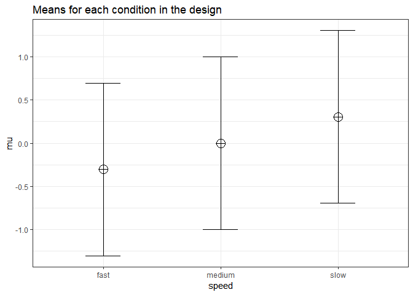

```r
ANOVA_power(design_result, nsims = nsims)
```

```
## Power and Effect sizes for ANOVA tests
##             power effect_size
## anova_speed 34.31      0.1137
##
## Power and Effect sizes for contrasts
##                           power effect_size
## p_speed_fast_speed_medium 15.21      0.3114
## p_speed_fast_speed_slow   47.96      0.6242
## p_speed_medium_speed_slow 14.64      0.3125
```

[figure not shown]

We can even check the calculation of Cohen’s f SPSS style in GPower. We take the GPower settings as illustrated above. We click the ‘Options’ button, and check the radio button next to ‘As in SPSS’. Click ok, and you will notice that the ‘Corr among rep measures’ field has disappeared. The correlation does not need to be entered separately, but is incorporated in Cohen’s f. The value of Cohen’s f, which was 0.25, has changed into 0.7024394. This is the SPSS equivalent. The value is much larger. This value, and it’s corresponding partial eta-squared, incorporate the correlation between observations.

[figure not shown]

## 2x2 ANOVA, within-between design

We can simulate a two-way ANOVA with a specific alpha, sample size and effect size, to achieve a specified statistical power. We will try to reproduce the power analysis in G*power for an *F*-test, ANOVA: Repeated measures, within-between interaction.

[figure not shown]

```r
mu <- c(-0.25, 0.25, 0.25, -0.25)
n <- 23
sd <- 1
r <- 0.5
string = "2w*2b"
alpha_level <- 0.05
labelnames = c("A", "a1", "a2", "B", "b1", "b2")
design_result <- ANOVA_design(string = string,
                              n = n,
                              mu = mu,
                              sd = sd,
                              r = r,
                              labelnames = labelnames)
```

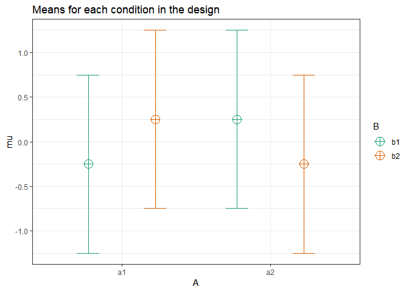

```r
simulation_result <- ANOVA_power(design_result, nsims = nsims)
```

```
## Power and Effect sizes for ANOVA tests
##           power effect_size
## anova_B    4.68      0.0102
## anova_A    5.09      0.0108
## anova_B:A 91.15      0.2103
##
## Power and Effect sizes for contrasts
##                       power effect_size
## p_A_a1_B_b1_A_a1_B_b2 38.19      0.5051
## p_A_a1_B_b1_A_a2_B_b1 62.66      0.5178
## p_A_a1_B_b1_A_a2_B_b2  5.39     -0.0039
## p_A_a1_B_b2_A_a2_B_b1  4.86      0.0024
## p_A_a1_B_b2_A_a2_B_b2 63.48     -0.5197
## p_A_a2_B_b1_A_a2_B_b2 38.34     -0.5113
```

We can simulate the same Two-Way ANOVA increasing the correlation to 0.7.

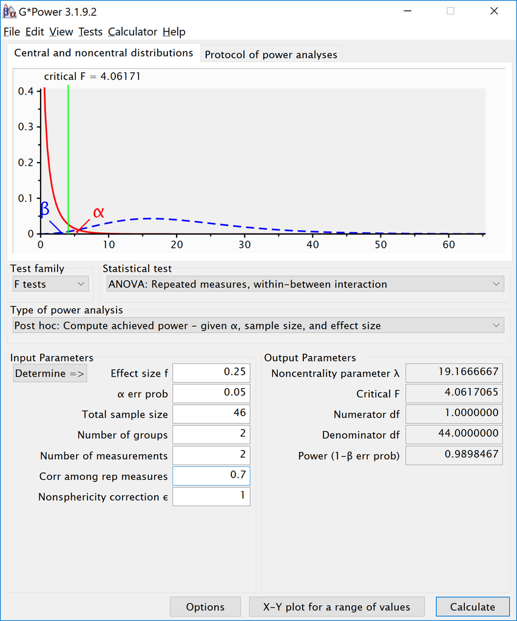

```r
mu <- c(-0.25, 0.25, 0.25, -0.25)
n <- 23
sd <- 1
r <- 0.7
string = "2w*2b"
alpha_level <- 0.05
labelnames = c("A", "a1", "a2", "B", "b1", "b2")
design_result <- ANOVA_design(string = string,
                              n = n,
                              mu = mu,
                              sd = sd,
                              r = r,
                              labelnames = labelnames)
```

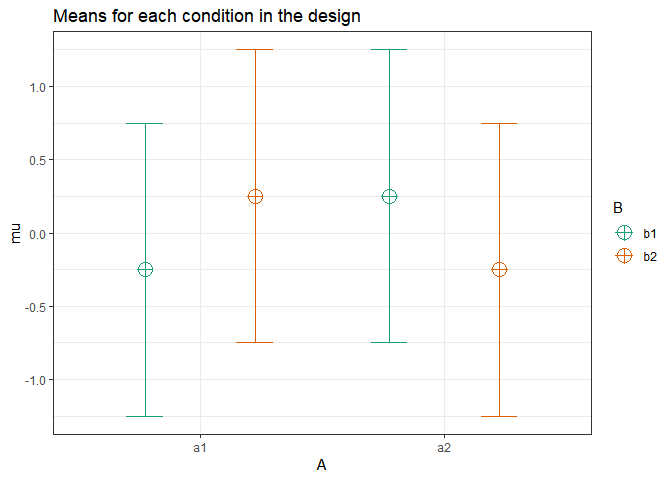

```r
simulation_result <- ANOVA_power(design_result, nsims = nsims)
```

```
## Power and Effect sizes for ANOVA tests
##           power effect_size
## anova_B    5.14      0.0104
## anova_A    4.68      0.0108
## anova_B:A 98.89      0.3056
##
## Power and Effect sizes for contrasts
##                       power effect_size
## p_A_a1_B_b1_A_a1_B_b2 38.21      0.5073
## p_A_a1_B_b1_A_a2_B_b1 83.95      0.6673
## p_A_a1_B_b1_A_a2_B_b2  5.44     -0.0023
## p_A_a1_B_b2_A_a2_B_b1  4.94      0.0010
## p_A_a1_B_b2_A_a2_B_b2 84.22     -0.6690
## p_A_a2_B_b1_A_a2_B_b2 38.50     -0.5098
```

## Two-way ANOVA, between participants Design

The effect size for interactions in ANOVA designs depends on the pattern of means. Let’s assume the researcher plans to perform an experiment where the voice of an artificial assistant sounds cheerful or sad, and as a second factor the voice sound more robotic or more human-like. Different patterns of results could be expected. Either the cheerful voices are appreciated more than sad voices for both human and robotic-sounding voice assistants. Or cheerful human voices are preferred above sad human voices, but no difference is expected for robotic voices, or the opposite effect is observed for robotic voices (a ‘Marvin-the-Depressed-Robot Effect’). In the first case, we will only observe a main effect of voice, but in the other two scenarios there is an interaction effect between human-likeness of the voice and the emotional tone of the voice. We can start by simulating the power for a cross-over interaction for a 2x2 between-participant design with 80 participants in each group (see the figure below for the expected pattern of means).

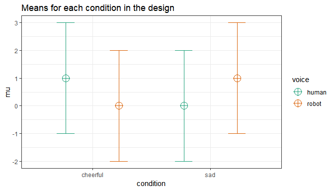

We can also examine the statistical power for a pattern of results that indicated that there was no difference in interacting with a cheerful of sad conversational agent with a robot voice. In this case, we expect an ‘ordinal’ interaction (the means for the human-like voice are never lower than the means for the robot-like voice, and thus there is no cross-over effect). The pattern of means is now 1, 0, 0, 0, with only a single mean that differs from the rest. These designs require larger samples sizes to have the same power to detect the interaction, compared to the two-group comparison. The reason for this is that the effect size is only half as large, with Cohen’s f = 0.125 (compared to 0.25 in the cross-over interaction). By steadily increasing the sample size in the simulation, we see that to achieve the same power as for the two-group comparison, a total sample size of 635 is required, almost four times as large as the sample size for the two-group comparison (160).

The power in the 2x2 ordinal interaction where only one cell mean differs from the other three cell means is identical to the power we would have if the single mean was twice as far from the remaining means (for a pattern of means of 2, 0, 0, 0). Similarly, if we would examine a 2x2x2 interaction where only one cell differs from the other means, Cohen’s f would be 0.25 when the pattern of means is 4, 0, 0, 0, 0, 0, 0, 0 across the eight cells. The take-home message is that a ‘medium’ effect size translates into a much more extreme pattern of means in an ordinal interaction than in a disordinal (crossover) interaction, or in a 2x2x2 interaction compared to a 2x2 interaction. It might therefore be more intuitive to perform a power analysis based on the expected pattern of means, and compute Cohen’s f based on this pattern, than to specify an effect size directly. The same effect size can represent very different patterns of means depending on the type of interaction and the number of factors.

### 3x3 Between Subject ANOVA

If we extend the design with an extra level for each factor, we have a 3x3 design (two factors, three levels each).

```r
string <- "3b*3b"
n <- 20
mu <- c(20, 20, 20, 20, 20, 20, 20, 20, 25) #All means are equal - so there is no real difference.
# Enter means in the order that matches the labels below.
sd <- 5
labelnames <- c("Factor_A", "a1", "a2", "a3", "Factor_B", "b1", "b2", "b3") #
# the label names should be in the order of the means specified above.

design_result <- ANOVA_design(string = string,
                   n = n,
                   mu = mu,
                   sd = sd,
                   labelnames = labelnames)
```

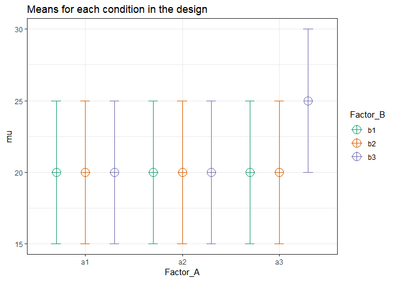

```r
power_result <- ANOVA_power(design_result, alpha_level = 0.05, nsims = nsims)
```

```
## Power and Effect sizes for ANOVA tests
##                         power effect_size
## anova_Factor_A          45.59      0.0315
## anova_Factor_B          44.83      0.0311
## anova_Factor_A:Factor_B 64.13      0.0652
##
## Power and Effect sizes for contrasts
##                                                   power effect_size
## p_Factor_A_a1_Factor_B_b1_Factor_A_a1_Factor_B_b2  5.15      0.0021
## p_Factor_A_a1_Factor_B_b1_Factor_A_a1_Factor_B_b3  4.85      0.0020
## p_Factor_A_a1_Factor_B_b1_Factor_A_a2_Factor_B_b1  4.88      0.0031
## p_Factor_A_a1_Factor_B_b1_Factor_A_a2_Factor_B_b2  4.87     -0.0010
## p_Factor_A_a1_Factor_B_b1_Factor_A_a2_Factor_B_b3  4.92      0.0017
## p_Factor_A_a1_Factor_B_b1_Factor_A_a3_Factor_B_b1  5.01      0.0056
## p_Factor_A_a1_Factor_B_b1_Factor_A_a3_Factor_B_b2  5.06      0.0063
## p_Factor_A_a1_Factor_B_b1_Factor_A_a3_Factor_B_b3 86.95      1.0233
## p_Factor_A_a1_Factor_B_b2_Factor_A_a1_Factor_B_b3  5.21      0.0005
## p_Factor_A_a1_Factor_B_b2_Factor_A_a2_Factor_B_b1  4.96      0.0010
## p_Factor_A_a1_Factor_B_b2_Factor_A_a2_Factor_B_b2  4.77     -0.0027
## p_Factor_A_a1_Factor_B_b2_Factor_A_a2_Factor_B_b3  5.16      0.0000
## p_Factor_A_a1_Factor_B_b2_Factor_A_a3_Factor_B_b1  4.97      0.0034
## p_Factor_A_a1_Factor_B_b2_Factor_A_a3_Factor_B_b2  5.06      0.0047
## p_Factor_A_a1_Factor_B_b2_Factor_A_a3_Factor_B_b3 86.24      1.0209
## p_Factor_A_a1_Factor_B_b3_Factor_A_a2_Factor_B_b1  5.20      0.0004
## p_Factor_A_a1_Factor_B_b3_Factor_A_a2_Factor_B_b2  4.68     -0.0032
## p_Factor_A_a1_Factor_B_b3_Factor_A_a2_Factor_B_b3  4.72     -0.0004
## p_Factor_A_a1_Factor_B_b3_Factor_A_a3_Factor_B_b1  4.95      0.0034
## p_Factor_A_a1_Factor_B_b3_Factor_A_a3_Factor_B_b2  4.83      0.0045
## p_Factor_A_a1_Factor_B_b3_Factor_A_a3_Factor_B_b3 87.52      1.0236
## p_Factor_A_a2_Factor_B_b1_Factor_A_a2_Factor_B_b2  5.07     -0.0036
## p_Factor_A_a2_Factor_B_b1_Factor_A_a2_Factor_B_b3  5.18     -0.0012
## p_Factor_A_a2_Factor_B_b1_Factor_A_a3_Factor_B_b1  5.03      0.0025
## p_Factor_A_a2_Factor_B_b1_Factor_A_a3_Factor_B_b2  5.12      0.0042
## p_Factor_A_a2_Factor_B_b1_Factor_A_a3_Factor_B_b3 86.57      1.0221
## p_Factor_A_a2_Factor_B_b2_Factor_A_a2_Factor_B_b3  4.96      0.0026
## p_Factor_A_a2_Factor_B_b2_Factor_A_a3_Factor_B_b1  4.90      0.0066
## p_Factor_A_a2_Factor_B_b2_Factor_A_a3_Factor_B_b2  4.85      0.0074
## p_Factor_A_a2_Factor_B_b2_Factor_A_a3_Factor_B_b3 86.58      1.0264
## p_Factor_A_a2_Factor_B_b3_Factor_A_a3_Factor_B_b1  5.02      0.0033
## p_Factor_A_a2_Factor_B_b3_Factor_A_a3_Factor_B_b2  4.94      0.0055
## p_Factor_A_a2_Factor_B_b3_Factor_A_a3_Factor_B_b3 86.85      1.0232
## p_Factor_A_a3_Factor_B_b1_Factor_A_a3_Factor_B_b2  4.84      0.0015
## p_Factor_A_a3_Factor_B_b1_Factor_A_a3_Factor_B_b3 86.59      1.0215
## p_Factor_A_a3_Factor_B_b2_Factor_A_a3_Factor_B_b3 87.04      1.0186
```

We can check these against the analytic solution.

```r
power_res <- power_twoway_between(design_result) #using default alpha level of .05

power_res$power_A
```

```
## [1] 0.4486306
```

```r
power_res$power_B
```

```
## [1] 0.4486306
```

```r
power_res$power_AB
```

```
## [1] 0.6434127
```

## Two by two ANOVA, within design

Potvin & Schutz (2000) simulate a wide range of repeated measure designs. The give an example of a 3x3 design, with the following correlation matrix:

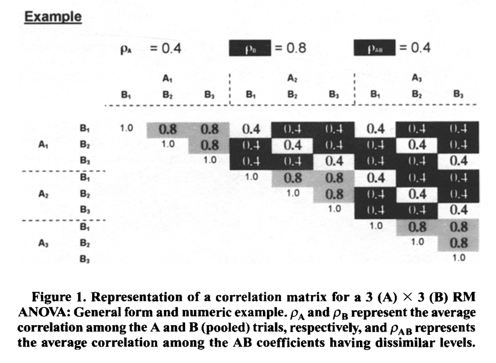

Potvin & Schulz (2000) examine power for 2x2 within ANOVA designs and develop approximations of the error variance. For a design with 2 within factors (A and B) these are:

For the main effect of A: (\sigma _ { e } ^ { 2 } = \sigma ^ { 2 } ( 1 - \overline { \rho } _ { A } ) + \sigma ^ { 2 } ( q - 1 ) ( \overline { \rho } _ { B } - \overline { \rho } _ { AB } ))

For the main effectof B: (\sigma _ { e } ^ { 2 } = \sigma ^ { 2 } ( 1 - \overline { \rho } _ { B } ) + \sigma ^ { 2 } ( p - 1 ) ( \overline { \rho } _ { A } - \overline { \rho } _ { A B } ))

For the interaction between A and B: (\sigma _ { e } ^ { 2 } = \sigma ^ { 2 } ( 1 - \rho _ { \max } ) - \sigma ^ { 2 } ( \overline { \rho } _ { \min } - \overline { \rho } _ { AB } ))

We first simulate a within subjects 2x2 ANOVA design.

```r
mu = c(2,1,4,2)
n <- 20
sd <- 5
r <- c(
  0.8, 0.5, 0.4,
       0.4, 0.5,
            0.8
  )

string = "2w*2w"
labelnames = c("A", "a1", "a2", "B", "b1", "b2")
design_result <- ANOVA_design(string = string,
                              n = n,
                              mu = mu,
                              sd = sd,
                              r = r,
                              labelnames = labelnames)
```

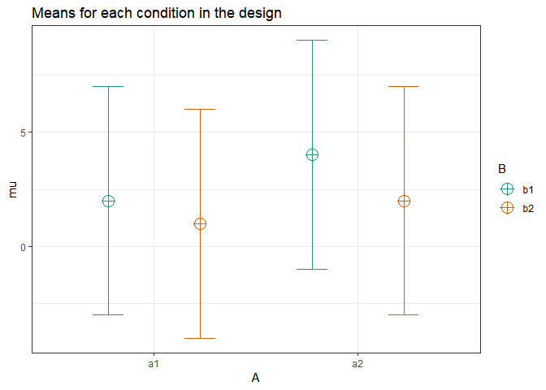

```r
simulation_result <- ANOVA_power(design_result, nsims = nsims)
```

```
## Power and Effect sizes for ANOVA tests
##           power effect_size
## anova_A   24.51      0.0871
## anova_B   24.23      0.0881
## anova_A:B  7.14      0.0290
##
## Power and Effect sizes for contrasts
##                       power effect_size
## p_A_a1_B_b1_A_a1_B_b2  9.34     -0.1997
## p_A_a1_B_b1_A_a2_B_b1 23.04      0.4078
## p_A_a1_B_b1_A_a2_B_b2  5.18     -0.0008
## p_A_a1_B_b2_A_a2_B_b1 44.60      0.6070
## p_A_a1_B_b2_A_a2_B_b2  9.28      0.1985
## p_A_a2_B_b1_A_a2_B_b2 23.36     -0.4086
```

We can use the analytic solution based on the formula in Potvin & Schutz (2000). I created a function ‘power_2x2_within’ that contains the calculations based on the formula above.

```r
power_res <- power_2x2_within(design_result = design_result)

power_res$power_A
```

```
## [1] 0.2470891
```

```r
power_res$power_B
```

```
## [1] 0.2470891
```

```r
power_res$power_AB
```

```
## [1] 0.07094116
```